# Heterogeneous GNN checkpoint: defend the whole pipeline

## Follow the computation

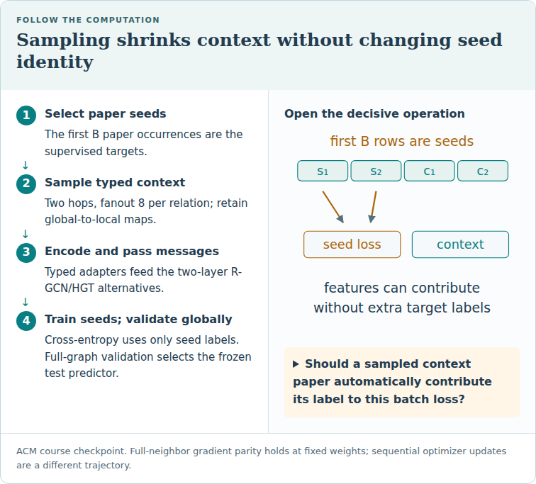

ACM course checkpoint. Full-neighbor gradient parity holds at fixed weights; sequential optimizer updates are a different trajectory.

**Trace question:** Should a sampled context paper automatically contribute its label to this batch loss?

**Trace answer:** No. Context can carry features without being a supervised seed. Keep the first-B seed boundary explicit.

Complete real three-type ACM experiment with native mini-batching. Teacher measurements are reference evidence; your execution and written defense remain separate. PENDING_WRITTEN_DEFENSE.

## Runtime setup — PROVIDED

The tested CPU environment is Python 3.12.3, torch 2.13.0+cpu, PyG 2.8.0.post1 and native pyg-lib 0.10.0 from commit `edc9e2a88d1c5d0953b5f69c98b8365597c6b699`. The executable model and trainer are inline; the notebook does not import the course repository. Native libraries must match your platform and torch ABI. Installation in a fresh environment and live Colab are **NOT_CHECKED**.

```
python -m pip install torch==2.13.0+cpu --extra-index-url https://download.pytorch.org/whl/cpu
python -m pip install torch-geometric==2.8.0.post1 numpy==2.5.0 scipy==1.18.0 rdflib==7.1.4 pandas==3.0.3 dill==0.3.8 cmake==4.4.3 ninja==1.13.2
MAX_JOBS=2 python -m pip install --no-build-isolation 'git+https://github.com/pyg-team/pyg-lib.git@edc9e2a88d1c5d0953b5f69c98b8365597c6b699'
```

If your existing Colab torch is incompatible, use a fresh matching runtime; do not reinterpret a missing extension as a passing sampling test. The core downloads the checksum-verified 20 MB ACM archive. The AIFB appendix downloads a separate verified archive. CS requires its separate 8.1 GiB archive and adequate resources.

```python
# @colab-bootstrap — this notebook's computation is fully inline; no course clone needed.
# Install the pinned runtime from the instructions above in a fresh environment first.
import sys, torch, torch_geometric
import torch_geometric.typing as pyg_typing
assert pyg_typing.WITH_PYG_LIB, 'Native pyg-lib is required. Follow the pinned install recipe above; do not skip sampling checks.'
print('Runtime:',sys.version.split()[0],torch.__version__,torch_geometric.__version__)
```

```
Runtime: 3.12.3 2.13.0+cpu 2.8.0.post1
```

**Your deliverable:** defend one trained heterogeneous GNN pipeline from table IDs to final held-out predictions.  
[Student notebook](https://avistian.github.io/relational/labs/0100-heterogeneous-gnn-checkpoint.ipynb) · [Executed solution](https://avistian.github.io/relational/labs/solutions/0100-heterogeneous-gnn-checkpoint.ipynb) · [Read the lab](https://avistian.github.io/relational/labs/html/0100-heterogeneous-gnn-checkpoint.html) · [Reproduction contract](https://avistian.github.io/relational/labs/l100-reproduction.md)

This is the Year 3 Q2 checkpoint. You already have individual operators, typed graph construction, sampling and comparison discipline. The tangible new skill is joining them into one pipeline whose result survives an audit. This supports the [mission](https://avistian.github.io/relational/MISSION.md): explain learned relational systems without hand-waving, and eventually evaluate them on real relational benchmarks.

A suggested route is the worked trace first; then the notebook tasks; then the complete experiment and written defense. The experiment can run while you prepare your protocol table. A prepared solution does not demonstrate your mastery.

## The big picture · defend the whole prediction procedure

THE BIG PICTURE · 100 / INTEGRATION AND DEFENSE

**Bring forward:** L091–L093 supply encoders; L096 supplies identity; L098 supplies batches; L099 supplies comparison discipline. **Follow:** legal graph → paired sampled dependencies → seed-only learning → validation selection → frozen prediction → written claim. **Carry forward:** temporal learning adds availability to every boundary already tested here.

[L096: typed keys](https://avistian.github.io/relational/lessons/0096-multi-relational-data.html) · [L098: seed boundaries](https://avistian.github.io/relational/lessons/0098-hetero-mini-batching.html) · [L099: model controls](https://avistian.github.io/relational/lessons/0099-rgcn-vs-hgt.html) · [L070: evidence defense](https://avistian.github.io/relational/lessons/0070-foundation-model-checkpoint.html) · [Sequence map](https://avistian.github.io/relational/reference/0091-0100-model-map.html)

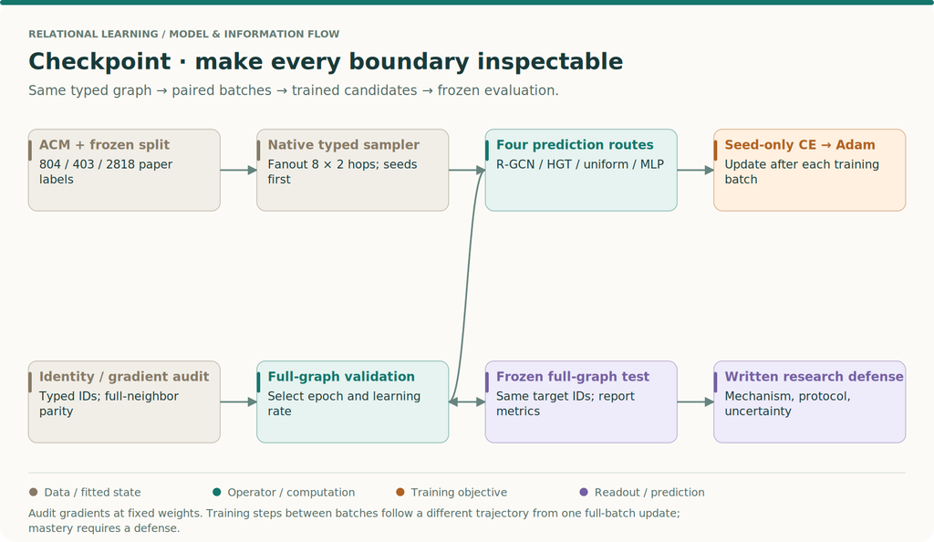

Same typed graph → paired batches → trained candidates → frozen evaluation. Audit gradients at fixed weights. Training steps between batches follow a different trajectory from one full-batch update; mastery requires a defense.

### Build an argument whose links can fail independently

Start with the final claim: one complete procedure obtained a measured score on fixed ACM targets. To defend it, recover the target IDs, reconstruct the allowed graph, identify the sampled inputs, trace the actual encoder, show which labels entered the loss, and reproduce the selected model's predictions. A correct last metric cannot repair an incorrect earlier identity map.

This is the same standard as [L040's exit exam](https://avistian.github.io/relational/lessons/0040-year-1-exit-exam.html) and L070's evidence chain, now applied to typed message passing. It is valid to conclude that graph context or attention did not help enough under this protocol. The checkpoint rewards a reconstructable claim, not a mandatory neural win.

### Trace one training seed across the interfaces

Select global paper ID 17. In its batch it occupies seed row 0. An author with global ID 2 may occupy author row 1, so a local author→paper edge `(1,0)` refers to `(author 2,paper 17)`. The author map and paper map are different functions. The encoder turns local typed features into hidden states; the classifier produces paper logits; seed row 0 contributes one training loss.

After selection, evaluate the frozen model on the full allowed graph and gather test IDs. Training batch positions are not persistent identities and must not become evaluation keys. The native [NeighborLoader contract](https://pytorch-geometric.readthedocs.io/en/2.6.1/_modules/torch_geometric/loader/neighbor_loader.html) and the source-pinned course checks make these handoffs explicit. The course sampler is not the HGT paper's HGSampling algorithm.

### Understand why a gradient audit can pass while training differs

Use a scalar parameter θ and two losses: `L₁=.5(θ−1)²`, `L₂=.5(θ+1)²`. Their equally weighted mean has gradient θ. At θ=0, one full-mean gradient step leaves θ at zero.

Now apply separate SGD steps of size .1. The first loss moves θ from 0 to .1. The second loss then has gradient 1.1, moving θ to −.01. Both per-example gradients were correct. They were evaluated at different parameters. This tiny teaching example isolates the same distinction as the checkpoint: an accumulated-gradient audit holds weights fixed, whereas ordinary mini-batch training updates between batches. Adam adds its own state to that difference.

The actual epoch also has unequal batch sizes. With 804 seeds and batches 256/256/256/36, the final batch's correct weight in a reported per-seed mean is `36/804≈.0448`, not .25. Correct reporting does not imply that the optimizer used the same trajectory as full-batch training. Keep objective accounting, gradient parity and optimization trajectory as three separate claims.

### Specify what every audit rules out

An ID round trip rules out a particular remapping error. A context-label perturbation rules out direct use of those labels in the seed loss. A full-neighbor forward comparison checks sampled dependency completeness under the audited operators. A fixed-weight gradient comparison checks objective weighting and differentiation. None of them establishes finite-fanout unbiasedness, historical paper reproduction, or general superiority across datasets.

The architecture sources remain [R-GCN](https://arxiv.org/html/1703.06103v4) and [HGT](https://arxiv.org/html/2003.01332v1); their published experiments remain distinct from this combined course comparison. Preserve every `INCOMPARABLE`, `NOT_ESTABLISHED` and `NOT_RUN` boundary in the ledger.

**Try first: what would make the final claim too broad?**

Claiming that HGT is generally better from three seeds on one static graph; calling a uniform-HGT contrast an isolated proof about attention without its optimization limits; or calling this native-sampler course run a reproduction of HGT's full paper protocol. State the observed comparison and its conditions instead.

**Your defense handoff.** Submit a trace for one typed edge, a derivation of the seed-weighted objective, and one paired result whose interpretation you could defend if its sign reversed. Then name the additional temporal availability checks needed for the next curriculum stage. The prepared artifacts support that defense; learner mastery remains **PENDING_WRITTEN_DEFENSE** until you write it.

## 2 · The integration gap

[L098](https://avistian.github.io/relational/lessons/0098-hetero-mini-batching.html) checked native sampling on a generated three-type graph. [L099](https://avistian.github.io/relational/lessons/0099-rgcn-vs-hgt.html) compared models on a real graph using full-graph updates. Neither alone establishes that the comparison remains correct after local node renumbering, seed masking and finite neighborhood sampling are combined.

> **In plain terms.** A sampler makes a small working copy of the neighborhood. Its row numbers change. Its context nodes are useful inputs, but they do not all become training targets.

We use every conference-filtered ACM paper from the [pinned DGL loader](https://github.com/dmlc/dgl/blob/3d16000b4170fa741ed9e9667f22ba84d3493026/examples/pytorch/han/utils.py): 4,025 papers, 7,167 connected authors and 60 connected subjects. Paper features are 1,903 row-normalized word counts. Author and subject features are constant ones. Four directed edge stores represent paper→author, its reverse, paper→subject and its reverse. They contain 34,864 directed edges in total.

The target is a three-class conference grouping. Conference membership supplies labels and is excluded from every input edge store and feature. Otherwise the graph would contain the answer. The fixed course split contains 804 training papers, 403 validation papers and 2,818 test papers.

**Transductive** means all graph features and edges are available when learning, including those of held-out papers. Their labels remain excluded from the training objective. This is a static information contract; it is not a future-prediction claim. [L101 in the roadmap](https://avistian.github.io/relational/plan/year-3.md) adds the harder question of when an edge or feature becomes available.

## 3 · Model architecture: a sampled computation with a fixed target boundary

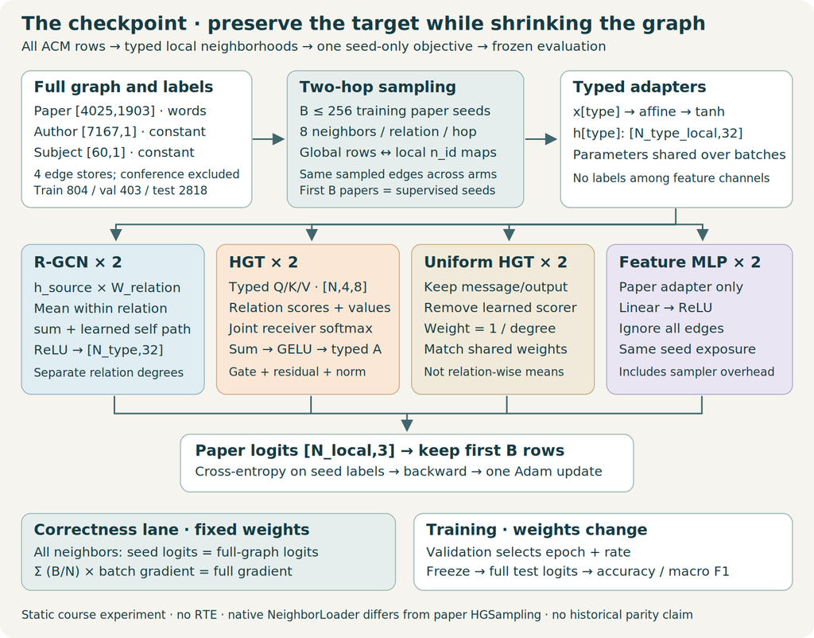

Trace one paper seed from full typed tables through native sampling, both message-passing layers and seed-only supervision. Full-graph evaluation follows frozen validation selection. On a narrow screen, scroll the figure horizontally.

### Follow one seed through the two layers

**Sample backward from the target.** Start with up to 256 training paper IDs. For each relation, the native loader samples at most eight incoming neighbors without replacement at each of two hops. A **fanout** is that per-receiver, per-relation limit. Two hops cover the dependencies of two message-passing layers. See the [NeighborLoader contract](https://pytorch-geometric.readthedocs.io/en/latest/modules/loader.html#torch_geometric.loader.NeighborLoader).

**Compute forward over local rows.** Each type has its own feature matrix `[N_type_in_batch, input_width]`. A type-specific affine adapter followed by tanh produces width 32. The same learned parameters are reused across batches. Edges use the batch's local row indices. They connect vectors inside this working graph, not arbitrary rows from the full tables.

**R-GCN branch.** For each receiver and relation, transform source vectors with that relation's matrix and average them. Sum the separate relation means, add the learned self transformation and apply ReLU. Repeat for layer two. This is the relation-normalized computation in [Schlichtkrull et al., Eq. 2](https://arxiv.org/html/1703.06103v4). The course wrapper adds feature adapters and a classifier; the named AIFB experiment has its own release architecture.

**HGT branch.** A head is one attention subspace; here four heads each have eight coordinates. Type-specific query, key and value projections produce the receiver query and source key/value. Relation-specific matrices transform keys and values. Dot-product scores, relation priors and division by √8 feed a softmax over all incoming edges for a receiver and head. The weighted message sum passes through GELU and a type-specific output map, then a learned gated residual and node-wise LayerNorm. Repeat twice. [Hu et al., §3](https://arxiv.org/html/2003.01332v1) motivates the typed attention route; the implementation follows the explicitly pinned modern release.

**Two controls.** Uniform HGT removes the score machinery and gives every incoming edge equal weight, retaining the message/output/residual route. Every common initial tensor matches HGT. The MLP uses paper features and ignores edges. It receives the same seed batches so its target exposure and update count match.

**Predict and train.** The classifier produces three logits per local paper. A logit is an unnormalized class score. Cross-entropy is the negative log probability assigned to the correct class after softmax. Only the first `B` paper logits belong to the requested training seeds. Context papers participate in message passing but contribute no direct label loss.

> **Scope check.** Native NeighborLoader is the controlled course sampler. It is not the paper's HGSampling algorithm. Static ACM has no relative temporal encoding. The full HGT CS lane retains its distinct sampler, time encoding, task and protocol.

## 4 · Worked trace: recover identities before trusting a score

**Worked example.** A batch has paper `n_id = [17, 4, 83]` and author `n_id = [9, 2]`. Here `n_id` maps local rows to global IDs within a type. Suppose there are two seed papers. The third paper, global ID 83, is context.

| Local author→paper edge | Global typed edge | Direct label loss? |
| --- | --- | --- |
| source 1 → receiver 0 | author 2 → paper 17 | Paper 17 is a seed |
| source 0 → receiver 2 | author 9 → paper 83 | Paper 83 is context |

The first endpoint must be looked up in the author map. The second must be looked up in the paper map. Applying the paper map to both endpoints creates plausible integers with incorrect meaning. The lab checks reconstructed endpoints against the original edge store indexed by `e_id`, the loader's original-edge map.

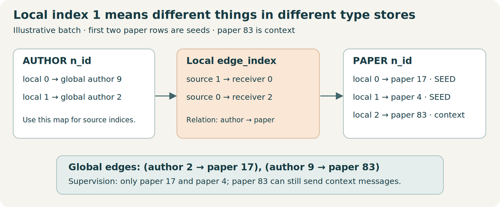

Illustrative typed ID trace: author local row 1 is author 2; paper local row 1 is paper 4. The type selects the correct map. On a narrow screen, scroll the figure horizontally.

**Your first two tasks:** implement `global_edges`, then `seed_loss`. The CHECK cells use deliberately different ID maps and change context labels. Correct seed loss remains unchanged; gradients on context output rows are zero. Context *features* can still receive gradients through their messages. No-gradient-on-context-logits is not no-learning-from-context.

## 5 · Three different claims about mini-batching

**Predict before reading:** if seed logits match, must sequential Adam updates match a full-batch update? Commit your answer first.

### Claim A: the same seed prediction

With all neighbors retained (`fanout=-1`), two sampled hops should reproduce each seed's two-layer full-graph prediction. This relies on having the complete relevant incoming neighborhoods, the same weights, no dropout and node-wise normalization. A graph-wide normalization layer or an insufficient number of sampled hops would require a different argument.

The audit compares float64 computations at a frozen absolute tolerance of `2e-6`. It checks an adversarial fixture with an isolated paper and empty relations, then 23 fixed training seeds on the full real ACM graph at batch sizes 1, 7 and 23. These probes test integration; they are not an exhaustive proof over every possible batch.

### Claim B: the same accumulated gradient

A batch loss is a mean over its `B` seeds. An epoch objective is a mean over `N` seeds. To recover the full objective, multiply each batch mean by `B/N`, add the results, and differentiate while holding the parameters fixed.

**Worked example.** Five individual losses are `[0.2, 0.8, 0.5, 1.1, 0.4]`. A batch size of three gives means 0.50 and 0.75. Their equally weighted mean is 0.625. The correct mean is `(3/5)×0.50 + (2/5)×0.75 = 0.60`. The shorter final batch must not receive the weight of a full batch.

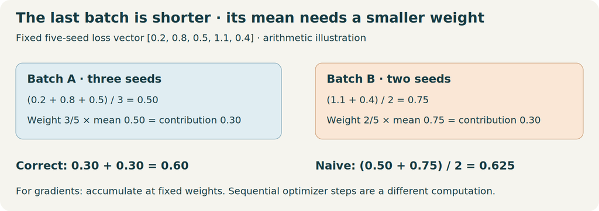

Fixed arithmetic example: changing batch partition cannot change the five-seed mean. A shorter batch contributes proportionally less. On a narrow screen, scroll the figure horizontally.

Your third task implements `batch_weight`. It is used by both the gradient audit and the reported epoch loss. For the real training split, the four batches have sizes 256, 256, 256 and 36. Equal averaging would over-weight the final 36 seeds.

### Claim C: the same optimizer trajectory

The audit does **not** step the optimizer between batches. The experiment **does**. Adam changes the weights and its moving state after each batch mean. Later gradients are therefore evaluated at different weights. Even all-neighbor sampling does not make those four steps identical to one full-batch step.

Finite fanout introduces another difference: the model sees a sampled neighborhood. A sampled mean may estimate a linear neighborhood mean under suitable sampling, but a nonlinear multi-layer prediction or attention normalization need not be an unbiased estimate of the full-graph prediction. Neither equal sample counts nor close scores establishes that property.

## 6 · Freeze the comparison before seeing test results

The experiment asks a narrow question: under this graph, split and fixed training budget, what does each complete prediction route achieve? The uniform-HGT intervention asks a narrower mechanism question inside the HGT family.

| Decision | Frozen rule |
| --- | --- |
| Information and targets | Same complete ACM graph, features and split for all arms |
| Sampling | Fanout 8 at two hops; batch 256; no replacement; directional edges |
| Paired samples | Seed order and sampled-edge fingerprints match across arms and rates for each seed/epoch |
| Model | Width 32, depth 2, HGT heads 4, dropout 0 |
| Training | Adam, weight decay .001, all 40 epochs, four updates per epoch |
| Search | Rates .003 and .01; seeds 0, 1 and 2 for each of four arms; 24 fits |
| Checkpoint | Earliest strictly lowest full-graph validation cross-entropy |
| Rate selection | Lowest mean selected validation loss across three seeds; smaller rate breaks ties |
| Test | Score selected checkpoints on the same complete test set after selection is frozen |
| Reporting | Accuracy, macro F1, individual seeds, paired differences, parameter counts and elapsed time |

**Macro F1** averages per-class F1 scores with equal class weights. For each class, F1 is `2TP/(2TP+FP+FN)`, with zero for an undefined denominator. **Sample SD** describes variation across these three initialization/sampling seeds. It does not describe variation across datasets or unknown future populations.

Sampling uses a separately reset epoch RNG: `100000 + 1000×seed + epoch_index`. Matching a seed label alone would be insufficient if different model initializations consumed different amounts of randomness. We also compare actual sample hashes across all eight fits associated with each seed. Uniform HGT copies common initial weights from HGT before training.

### Equal seed labels do not guarantee equal sampled inputs

A pseudorandom generator produces a sequence. Model initialization can consume part of that sequence before sampling begins. This CPU diagnostic uses the same initial seed in both cases:

```
torch.manual_seed(17)
torch.randn(3)                 # stand-in for one initialization
a = torch.randperm(8)[:3]      # [6, 0, 4]
torch.manual_seed(17)
torch.randn(7)                 # stand-in for a larger initialization
b = torch.randperm(8)[:3]      # [6, 7, 3]
```

The draw counts are a teaching fixture, not the actual models' parameter counts. The exact IDs are observed in the recorded CPU environment; the important fact is that the generator reaches different positions. Merely writing “seed 17” beside both runs does not establish paired inputs.

Resetting to the sampling seed `100000` immediately before each permutation gives `[1, 2, 4]` in both cases. The actual trainer similarly resets at each epoch, then checks **the resulting seed order, per-type node IDs and global typed edge endpoints**. Its sample hashes compare those contents across arms and rates. Matching counts alone would not establish that the same neighbors were used.

**Exercise:** if one arm gains dropout between sampler batches, does resetting only at the start of the epoch still guarantee paired inputs?

**Follow the random draws between batches**

No. A stochastic model operation can consume the shared generator before the next neighborhood draw. The current experiment has dropout zero. A changed harness would need verified separation of random streams or explicitly shared sampled batches, plus the same content checks. A seed convention is a recipe; matching sampled identities is evidence that the recipe achieved pairing.

Equal width, update count and search size do not give equal parameter counts, FLOPs or optimization quality. The MLP still pays sampler overhead in this harness, so elapsed times are pipeline measurements, not isolated model-speed benchmarks. Validation and final test inference use the full graph; this course experiment does not establish a scalable all-sampled deployment.

## 7 · Inspect the measured evidence

Before opening the result table, predict which comparison could justify a statement about learned attention. Then explain one alternative explanation for a family-level difference.

| Arm | LR | Accuracy mean ± seed SD | Macro F1 mean | Parameters | Seconds per selected fit |
| --- | --- | --- | --- | --- | --- |
| rgcn | 0.003 | 49.54% ± 0.00 pp | 0.2209 | 71,459 | 6.58 |
| hgt | 0.003 | 88.81% ± 0.90 pp | 0.8878 | 91,017 | 18.26 |
| hgt_uniform | 0.003 | 87.11% ± 1.41 pp | 0.8701 | 76,265 | 12.04 |
| mlp | 0.003 | 70.96% ± 1.42 pp | 0.6305 | 63,139 | 3.47 |

| Seed | HGT − R-GCN | HGT − uniform HGT | HGT − MLP |
| --- | --- | --- | --- |
| 0 | +39.11 pp | +0.64 pp | +18.56 pp |
| 1 | +40.24 pp | +4.29 pp | +17.18 pp |
| 2 | +38.47 pp | +0.18 pp | +17.81 pp |

**Author-reference evidence:** all 24 fits, 960 epochs and 3,840 optimizer updates completed. HGT exceeds the uniform ablation by 1.70 percentage points on average here. This is conditional evidence under one fixed protocol, not a universal attention benefit. R-GCN predicts the majority class for all test papers in every selected run (49.54% accuracy); its failed learning trajectory limits the family comparison. The experiment is retained as specified.

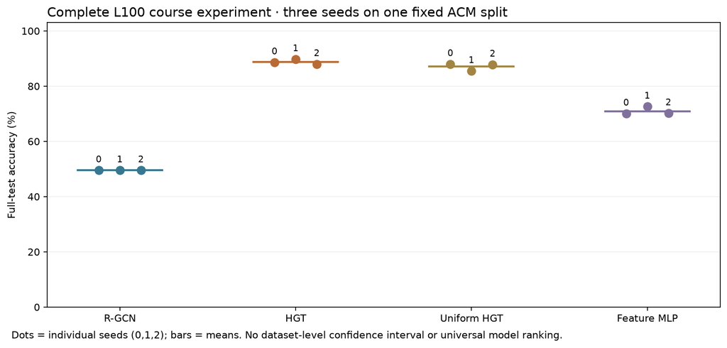

Measured complete course run. Each point is one seed on the same graph/split; horizontal bars are means. These are not independent datasets. On a narrow screen, scroll the figure horizontally.

A weak R-GCN result under this fixed budget does not establish that relation-specific models are intrinsically weak. Optimization, the constant auxiliary features, the split and the wrapper all matter. An attention ablation changes parameter count and training dynamics as well as the weighting rule. Carry these limitations into the attribution table, rather than deleting an inconvenient result.

L099 used 60 full-batch steps; L100 uses 160 mini-batch steps and finite fanout. Comparing their scores changes several factors simultaneously. It is not a clean estimate of the causal effect of sampling. A follow-up would hold the optimizer/update schedule fixed and vary the sampler, using new validation-only decisions.

## 8 · Full reproduction: inspect the target, protocol and executed coverage

The [R-GCN paper](https://arxiv.org/abs/1703.06103v4) and [HGT paper](https://arxiv.org/abs/2003.01332v1) introduce methods and multiple experiments. Completing our checkpoint does not reproduce all those experiments.

| Evidence lane | What is provided | What it establishes |
| --- | --- | --- |
| ACM checkpoint | All 24 fresh course fits, 960 epochs, 3,840 updates; traces/checkpoints/predictions | The complete declared course experiment, not a published table |
| R-GCN AIFB | Fresh ten-run full release-protocol port, original 140/36 split and full graph | A named published target comparison; historical identity remains INCOMPARABLE |
| HGT CS Table 2 | Full-setting model/sampler/trainer, pinned 8.1 GiB data identity, five-seed local/Modal/notebook commands | Runnable reconstruction track; full training NOT_RUN |
| Entire original papers | Other tasks/datasets and historical tuning/backend remain outside executed coverage | Full-paper parity NOT_ESTABLISHED |

The fresh AIFB mean is **95.8333%**, with **1.4640 percentage points** sample SD across ten runs. The Table 2 target is 95.83%. Numerical closeness is a useful observation; it does not identify the historical graph bytes, RNG sequence or Keras/Theano execution. The lab appendix visibly includes the complete AIFB implementation and trainer.

For HGT, CS Paper–Field L2 targets NDCG .403 ± .041 and MRR .439 ± .078 across five trainings. The course's full-setting port uses width 256, three layers and eight heads, with the source/deviation ledger linked below. The modern source differs from the archived publication-era code. L093 previously recorded a 10 GiB guarded load failure and a Modal GPU payment-method rejection. These are **prior findings**, not a fresh capacity experiment here. We do not relabel ACM, NN or a single update as the CS result.

The [full contract](https://avistian.github.io/relational/labs/l100-reproduction.md) records hashes, exact commands, model/optimizer/data/split/metric differences and delivery evidence. The standalone notebook contains the full visible CS implementation in a gated appendix. Turning on a flag does not upgrade a verdict; completed evidence must do that.

## 9 · EXIT: defend the pipeline

Submit the three task implementations, your fresh JSON evidence and an attribution table with columns **observation / held fixed / changed / alternative explanation / justified conclusion**. Include one row for HGT versus R-GCN, one for HGT versus uniform HGT and one for the all-neighbor parity audit.

Defend these five questions without reopening the solution:

1. Trace one sampled edge from local indices to global typed IDs, then through both layers to a seed prediction.
2. Explain why a context paper can send useful messages while its label remains excluded from the batch objective.
3. Derive the `B/N` weight for an incomplete final batch. State exactly when accumulated gradients match and when optimizer trajectories can differ.
4. Use the paired results to distinguish an architecture gap from an attention effect. Name one unresolved confound and one useful next experiment.
5. Explain why complete ACM execution, close AIFB scores and an unrun HGT CS operator have different reproduction statuses.

The teacher scores five axes 0–2: identity/graph contract; sampling/loss correctness; reproducible execution; comparison reasoning; reproduction defense. A checkpoint pass requires at least 8/10 and no zero in correctness or reproduction defense. Until your own artifacts and explanation are reviewed, status remains **PENDING_WRITTEN_DEFENSE**.

**Teach back:** explain the boundary between prediction parity, gradient parity, optimizer trajectories and historical reproduction.

Ask the agent follow-up questions about any unclear step, or paste your EXIT evidence for a strict defense. Revisit the identity trace tomorrow and the gradient-versus-update distinction in a week. Next, [the temporal quarter](https://avistian.github.io/relational/plan/year-3.md) asks whether each input existed at prediction time—an issue this static checkpoint deliberately leaves open.

## Core lab · visible implementation

Read one coherent function at a time. Tasks 1–3 feed the actual sampler audit and training pipeline. The model operators follow L099; the new integration begins at as_heterodata. PROVIDED does not mean unimportant: trace one seed through Model.forward before running the experiment.

```python
import copy, hashlib, json, math, platform, time, urllib.request

from pathlib import Path

import numpy as np

import scipy.io as sio

import torch

from torch import nn

from torch.nn import functional as F

ROUTES = [(0,1),(1,0),(0,2),(2,0)]

ARMS = ['rgcn','hgt','hgt_uniform','mlp']

DATA_URL = 'https://data.dgl.ai/dataset/ACM.mat'

DATA_SHA256 = '0ccd838e545e8f16e3dc84356da2f51dfd2290c32e37a784e374dd510c76578d'

LEARNING_RATES = [.003,.01]

SEEDS = [0,1,2]

EPOCHS = 40

from torch_geometric.data import HeteroData

from torch_geometric.loader import NeighborLoader

import torch_geometric

import torch_geometric.typing as pyg_typing

TYPES = ('paper','author','subject')

EDGE_TYPES = (('paper','written_by','author'),('author','writes','paper'),
              ('paper','has_subject','subject'),('subject','describes','paper'))

BATCH_SIZE = 256

FANOUT = 8
```

### PROVIDED · relation_mean

mean incoming source rows per receiver; empty neighborhoods return zero.

```python
def relation_mean(x, edge, receivers):
    """ mean incoming source rows per receiver; empty neighborhoods return zero."""
    src,dst=edge
    out=x.new_zeros((receivers,x.shape[1])).index_add(0,dst,x[src])
    degree=torch.bincount(dst,minlength=receivers).clamp_min(1)
    return out/degree[:,None]
```

### PROVIDED · receiver_softmax

stable E×heads softmax over ALL incoming relations per receiver/head.

```python
def receiver_softmax(scores, dst, receivers):
    """ stable E×heads softmax over ALL incoming relations per receiver/head."""
    ix=dst[:,None].expand_as(scores)
    maximum=scores.new_full((receivers,scores.shape[1]),-torch.inf)
    maximum.scatter_reduce_(0,ix,scores.detach(),reduce='amax',include_self=True)
    weights=(scores-maximum[dst]).exp()
    denominator=scores.new_zeros(maximum.shape).scatter_add(0,ix,weights)
    return weights/denominator[dst].clamp_min(torch.finfo(scores.dtype).tiny)
```

### PROVIDED · choose_config

minimize mean best validation CE across seeds; ties use smaller LR.

```python
def choose_config(records, arm):
    """ minimize mean best validation CE across seeds; ties use smaller LR."""
    rates=sorted({r['lr'] for r in records if r['arm']==arm})
    return min(rates,key=lambda lr:(np.mean([r['best_val_ce'] for r in records if r['arm']==arm and r['lr']==lr]),lr))
```

### PROVIDED · load_graph

Full DGL ACM conference-filtered graph; fixed course split; no conference edges.

```python
def load_graph(root):
    """Full DGL ACM conference-filtered graph; fixed course split; no conference edges."""
    root=Path(root);root.mkdir(parents=True,exist_ok=True);path=root/'ACM.mat'
    if not path.exists():
        with urllib.request.urlopen(DATA_URL,timeout=120) as r:payload=r.read()
        if hashlib.sha256(payload).hexdigest()!=DATA_SHA256:raise ValueError('Download hash mismatch')
        path.write_bytes(payload)
    if hashlib.sha256(path.read_bytes()).hexdigest()!=DATA_SHA256:raise ValueError('Dataset hash mismatch')
    raw=sio.loadmat(path,spmatrix=True)
    conf_ids=[0,1,9,10,13];label_ids=[0,1,2,2,1]
    ids=np.flatnonzero(np.asarray(raw['PvsC'][:,conf_ids].sum(1)).ravel())
    conference=raw['PvsC'][ids].toarray().argmax(1)
    labels=np.array([dict(zip(conf_ids,label_ids))[c] for c in conference])
    features=raw['PvsT'][ids].toarray().astype('float32')
    features/=np.maximum(features.sum(1,keepdims=True),1)
    xs=[torch.from_numpy(features)];edges=[];node_ids=[ids.tolist()]
    for key in ['PvsA','PvsL']:
        incidence=raw[key][ids].tocsr();connected=np.flatnonzero(np.asarray(incidence.sum(0)).ravel())
        incidence=incidence[:,connected];a,b=incidence.nonzero()
        edge=torch.tensor(np.stack([a,b]),dtype=torch.long)
        edges.extend([edge,edge.flip(0)]);xs.append(torch.ones((len(connected),1)));node_ids.append(connected.tolist())
    rng=np.random.RandomState(99);parts=[[],[],[]]
    for c in range(3):
        perm=rng.permutation(np.flatnonzero(labels==c));n=len(perm);a=int(.2*n);b=int(.3*n)
        for acc,subset in zip(parts,[perm[:a],perm[a:b],perm[b:]]):acc.extend(subset.tolist())
    parts=[torch.tensor(sorted(v),dtype=torch.long) for v in parts]
    assert len(ids)==4025 and [len(t) for t in xs]==[4025,7167,60]
    assert len(torch.unique(torch.cat(parts)))==len(ids)
    assert [e.shape[1] for e in edges]==[13407,13407,4025,4025]
    meta={'data_url':DATA_URL,'data_sha256':DATA_SHA256,'nodes':[len(t) for t in xs],
          'features':[t.shape[1] for t in xs],'directed_edges':[e.shape[1] for e in edges],
          'raw_node_ids':node_ids,'split_seed':99,'split_sizes':[len(p) for p in parts],
          'split_sha256':hashlib.sha256(b''.join(p.numpy().tobytes() for p in parts)).hexdigest(),
          'graph_sha256':hashlib.sha256(b''.join(e.numpy().tobytes() for e in edges)).hexdigest(),
          'access':'transductive; all selected paper features/edges; labels only in masked objective/validation/scoring',
          'forbidden_input':'PvsC: conference incidence supplies labels only, never edges/features'}
    return {'x':xs,'edges':edges,'y':torch.tensor(labels),'train':parts[0],'val':parts[1],'test':parts[2],'meta':meta}
```

### PROVIDED · RGCNLayer

Eq2 relation-wise mean, sum over relations, one learned self transform, ReLU.

```python
class RGCNLayer(nn.Module):
    """Eq2 relation-wise mean, sum over relations, one learned self transform, ReLU."""
    def __init__(self,width):
        super().__init__();self.weights=nn.Parameter(torch.empty(4,width,width));self.self_linear=nn.Linear(width,width)
        for w in self.weights:nn.init.xavier_uniform_(w)
    def forward(self,x,edges):
        out=[self.self_linear(t) for t in x]
        for r,(source,target) in enumerate(ROUTES):
            out[target]=out[target]+relation_mean(x[source]@self.weights[r],edges[r],len(x[target]))
        return [z.relu() for z in out]
```

### PROVIDED · HGTLayer

Typed multi-head attention with cross-relation normalization and gated residual. uniform=True removes Q/K, relation attention matrices and priors, retaining V, relation message matrices, A, skip and LayerNorm. No temporal encoding on ACM.

```python
class HGTLayer(nn.Module):
    """Typed multi-head attention with cross-relation normalization and gated residual.
    uniform=True removes Q/K, relation attention matrices and priors, retaining V,
    relation message matrices, A, skip and LayerNorm. No temporal encoding on ACM.
    """
    def __init__(self,width,heads=4,uniform=False):
        super().__init__();self.width=width;self.heads=heads;self.d=width//heads;self.uniform=uniform
        if width%heads:raise ValueError('width must be divisible by heads')
        if not uniform:
            self.k_linears=nn.ModuleList([nn.Linear(width,width) for _ in range(3)])
            self.q_linears=nn.ModuleList([nn.Linear(width,width) for _ in range(3)])
        self.v_linears=nn.ModuleList([nn.Linear(width,width) for _ in range(3)])
        self.a_linears=nn.ModuleList([nn.Linear(width,width) for _ in range(3)])
        self.norms=nn.ModuleList([nn.LayerNorm(width) for _ in range(3)])
        if not uniform:
            self.relation_pri=nn.Parameter(torch.ones(4,heads))
            self.relation_att=nn.Parameter(torch.empty(4,heads,self.d,self.d))
        self.relation_msg=nn.Parameter(torch.empty(4,heads,self.d,self.d));self.skip=nn.Parameter(torch.ones(3))
        if not uniform:nn.init.uniform_(self.relation_att,-math.sqrt(3/self.d),math.sqrt(3/self.d))
        nn.init.uniform_(self.relation_msg,-math.sqrt(3/self.d),math.sqrt(3/self.d))
    def forward(self,x,edges):
        values=[f(z).view(-1,self.heads,self.d) for f,z in zip(self.v_linears,x)]
        if not self.uniform:
            keys=[f(z).view(-1,self.heads,self.d) for f,z in zip(self.k_linears,x)]
            queries=[f(z).view(-1,self.heads,self.d) for f,z in zip(self.q_linears,x)]
        messages=[[],[],[]];scores=[[],[],[]];receivers=[[],[],[]]
        for r,(s,t) in enumerate(ROUTES):
            src,dst=edges[r]
            msg=torch.einsum('ehd,hdf->ehf',values[s][src],self.relation_msg[r])
            if self.uniform:score=msg.new_zeros((len(src),self.heads))
            else:
                key=torch.einsum('ehd,hdf->ehf',keys[s][src],self.relation_att[r])
                score=(queries[t][dst]*key).sum(-1)*self.relation_pri[r]/math.sqrt(self.d)
            messages[t].append(msg);scores[t].append(score);receivers[t].append(dst)
        out=[]
        for t in range(3):
            dst=torch.cat(receivers[t]);alpha=receiver_softmax(torch.cat(scores[t]),dst,len(x[t]))
            weighted=(torch.cat(messages[t])*alpha[:,:,None]).reshape(-1,self.width)
            aggregate=x[t].new_zeros(x[t].shape).index_add(0,dst,weighted)
            a=self.skip[t].sigmoid();out.append(self.norms[t](a*self.a_linears[t](F.gelu(aggregate))+(1-a)*x[t]))
        return out
```

### PROVIDED · Model

Same width32, depth2, adapters and classifier; family-specific hidden operators.

```python
class Model(nn.Module):
    """Same width32, depth2, adapters and classifier; family-specific hidden operators."""
    def __init__(self,inputs,arm,width=32):
        super().__init__();self.arm=arm
        if arm not in ARMS:raise ValueError(arm)
        self.adapters=nn.ModuleList([nn.Linear(d,width) for d in (inputs[:1] if arm=='mlp' else inputs)])
        if arm=='mlp':self.layers=nn.ModuleList([nn.Linear(width,width) for _ in range(2)])
        else:self.layers=nn.ModuleList([RGCNLayer(width) if arm=='rgcn' else HGTLayer(width,uniform=arm=='hgt_uniform') for _ in range(2)])
        self.classifier=nn.Linear(width,3)
    def forward(self,g):
        x=[torch.tanh(f(t)) for f,t in zip(self.adapters,g['x'])]
        for layer in self.layers:x=[layer(x[0]).relu()] if self.arm=='mlp' else layer(x,g['edges'])
        return self.classifier(x[0])
```

### PROVIDED · classification_metrics

Accuracy and macro F1; three fixed classes, zero undefined F1.

```python
def classification_metrics(truth,prediction):
    """Accuracy and macro F1; three fixed classes, zero undefined F1."""
    truth=np.asarray(truth);prediction=np.asarray(prediction);f=[]
    for c in range(3):
        tp=np.sum((truth==c)&(prediction==c));fp=np.sum((truth!=c)&(prediction==c));fn=np.sum((truth==c)&(prediction!=c))
        f.append(float(2*tp/max(2*tp+fp+fn,1)))
    return {'accuracy':float(np.mean(truth==prediction)),'macro_f1':float(np.mean(f))}
```

### PROVIDED · as_heterodata

Preserve separate node-ID spaces; target labels never become features or edges.

```python
def as_heterodata(g):
    """Preserve separate node-ID spaces; target labels never become features or edges."""
    data=HeteroData()
    for t,x in zip(TYPES,g['x']):data[t].x=x
    data['paper'].y=g['y']
    for e,edge in zip(EDGE_TYPES,g['edges']):data[e].edge_index=edge
    return data
```

### PROVIDED · make_loader

Two directional hops for two layers; native sampling without replacement.

```python
def make_loader(data,seeds,fanout=FANOUT,batch_size=BATCH_SIZE):
    """Two directional hops for two layers; native sampling without replacement."""
    if not pyg_typing.WITH_PYG_LIB:raise RuntimeError('Native pyg-lib required; no stand-in sampler is permitted')
    return NeighborLoader(data,input_nodes=('paper',torch.as_tensor(seeds,dtype=torch.long)),
        num_neighbors={e:[fanout,fanout] for e in EDGE_TYPES},batch_size=batch_size,
        shuffle=False,replace=False,num_workers=0,subgraph_type='directional')
```

### PROVIDED · local_graph

The same visible model accepts full or sampled local typed feature/edge arrays.

```python
def local_graph(batch):
    """The same visible model accepts full or sampled local typed feature/edge arrays."""
    return {'x':[batch[t].x for t in TYPES],'edges':[batch[e].edge_index for e in EDGE_TYPES]}
```

### TODO · global_edges

TODO 1: reconstruct global source and destination IDs using their own type maps.

```python
def global_edges(batch,edge_type):
    """TODO 1: reconstruct global source and destination IDs using their own type maps."""
    source,_,target=edge_type
    a,b=batch[edge_type].edge_index
    return torch.stack([batch[source].n_id[a],batch[target].n_id[b]])
```

### CHECK · global_edges

```python
batch=HeteroData()
batch['paper'].n_id=torch.tensor([17,4,83]);batch['author'].n_id=torch.tensor([9,2])
e=('author','writes','paper');batch[e].edge_index=torch.tensor([[1,0],[0,2]])
assert torch.equal(global_edges(batch,e),torch.tensor([[2,9],[17,83]])), 'Use the source and destination type maps separately'
print('PASS: typed local-to-global endpoint trace')
```

```
PASS: typed local-to-global endpoint trace
```

### TODO · seed_loss

TODO 2: mean three-class cross-entropy over the first B seed papers only.

```python
def seed_loss(logits,batch):
    """TODO 2: mean three-class cross-entropy over the first B seed papers only."""
    b=batch['paper'].batch_size
    return F.cross_entropy(logits[:b],batch['paper'].y[:b])
```

### CHECK · seed_loss

```python
batch=HeteroData();batch['paper'].y=torch.tensor([0,2,1]);batch['paper'].batch_size=2
z=torch.tensor([[1.,0.,-1.],[0.,1.,2.],[8.,1.,0.]],requires_grad=True)
a=seed_loss(z,batch);a.backward()
assert torch.allclose(a,F.cross_entropy(z[:2],torch.tensor([0,2])))
assert torch.equal(z.grad[2:],torch.zeros_like(z.grad[2:])), 'Context output rows must have no direct supervised gradient'
batch['paper'].y[2]=0;assert torch.equal(seed_loss(z,batch),a)
print('PASS: only seed labels affect the objective')
```

```
PASS: only seed labels affect the objective
```

### TODO · batch_weight

TODO 3: weight a batch mean to recover the mean over all seeds, including a short final batch. Reject empty or oversized batches. This weights the audit and epoch report; the training optimizer still steps after each unweighted batch mean.

```python
def batch_weight(batch_count,total_count):
    """TODO 3: weight a batch mean to recover the mean over all seeds, including a short final batch.
    Reject empty or oversized batches. This weights the audit and epoch report;
    the training optimizer still steps after each unweighted batch mean.
    """
    if not 0<batch_count<=total_count:raise ValueError('Require 0 < batch_count <= total_count')
    return batch_count/total_count
```

### CHECK · batch_weight

```python
assert abs(batch_weight(3,5)*.5+batch_weight(2,5)*.75-.6)<1e-12
assert abs(sum(batch_weight(b,804) for b in [256,256,256,36])-1)<1e-12
for args in [(0,5),(6,5),(2,0)]:
    try:batch_weight(*args)
    except ValueError:pass
    else:raise AssertionError('Invalid batch size accepted')
print('PASS: unequal final batch and invalid inputs')
```

```
PASS: unequal final batch and invalid inputs
```

### PROVIDED · initialize

Copy every shared HGT tensor into the uniform ablation; seeds alone do not ensure this.

```python
def initialize(g,arm,seed,width=32):
    """Copy every shared HGT tensor into the uniform ablation; seeds alone do not ensure this."""
    torch.manual_seed(seed);model=Model([x.shape[1] for x in g['x']],arm,width)
    if arm=='hgt_uniform':
        torch.manual_seed(seed);reference=Model([x.shape[1] for x in g['x']],'hgt',width)
        state=reference.state_dict();model.load_state_dict({k:state[k] for k in model.state_dict()})
    return model
```

### PROVIDED · audit_batches

All-neighbor seed logits and accumulated CE gradients must match a full-graph forward. Fixed weights, no optimizer steps, node-wise LayerNorm and no dropout. Float64 audit isolates algebra from float32 rounding. Tolerance fixed at 2e-6.

```python
def audit_batches(g,arm,batch_size,width=32,seeds=None):
    """All-neighbor seed logits and accumulated CE gradients must match a full-graph forward.
    Fixed weights, no optimizer steps, node-wise LayerNorm and no dropout.
    Float64 audit isolates algebra from float32 rounding. Tolerance fixed at 2e-6.
    """
    seeds=torch.arange(len(g['y'])) if seeds is None else torch.as_tensor(seeds)
    gd={**g,'x':[x.double() for x in g['x']]};data=as_heterodata(gd)
    model=initialize(gd,arm,100,width).double();reference=copy.deepcopy(model)
    full=reference(gd);F.cross_entropy(full[seeds],g['y'][seeds]).backward()
    gap=0.;seen=[];batch_counts=[]
    for batch in make_loader(data,seeds,-1,batch_size):
        b=batch['paper'].batch_size;ids=batch['paper'].n_id[:b];seen.extend(ids.tolist())
        logits=model(local_graph(batch));gap=max(gap,float((logits[:b]-full[ids]).abs().max().detach()))
        (seed_loss(logits,batch)*batch_weight(b,len(seeds))).backward()
        for e in EDGE_TYPES:assert torch.equal(global_edges(batch,e),data[e].edge_index[:,batch[e].e_id])
        batch_counts.append({'seeds':b,'nodes':sum(batch[t].num_nodes for t in TYPES),'edges':sum(batch[e].num_edges for e in EDGE_TYPES)})
    grad_gap=max(float(((a.grad if a.grad is not None else torch.zeros_like(a))-(b.grad if b.grad is not None else torch.zeros_like(b))).abs().max()) for a,b in zip(model.parameters(),reference.parameters()))
    assert seen==seeds.tolist() and len(set(seen))==len(seen)
    assert gap<2e-6 and grad_gap<2e-6,(arm,gap,grad_gap)
    return {'arm':arm,'batch_size':batch_size,'max_logit_gap':gap,'max_gradient_gap':grad_gap,'seed_coverage':seen,'batch_counts':batch_counts}
```

### PROVIDED · fit

Identical epoch seed order/samples across arms and rates; validation only checkpointing. Training uses one Adam update per batch mean, NOT gradient accumulation. Evaluation uses the entire graph, which fits in memory for this dataset.

```python
def fit(g,arm,lr,seed,epochs=EPOCHS,width=32,batch_size=BATCH_SIZE):
    """Identical epoch seed order/samples across arms and rates; validation only checkpointing.
    Training uses one Adam update per batch mean, NOT gradient accumulation.
    Evaluation uses the entire graph, which fits in memory for this dataset.
    """
    model=initialize(g,arm,seed,width);data=as_heterodata(g)
    optimizer=torch.optim.Adam(model.parameters(),lr=lr,weight_decay=.001)
    best=float('inf');checkpoint=None;trace=[];sample_hashes=[];start=time.perf_counter()
    max_nodes=0;max_edges=0
    for epoch in range(epochs):
        # Reset sampling RNG independently of initialization and model parameter count.
        torch.manual_seed(100000+seed*1000+epoch)
        order=g['train'][torch.randperm(len(g['train']))]
        model.train();total=0.;h=hashlib.sha256();seen=[];updates=0
        for batch in make_loader(data,order,FANOUT,batch_size):
            b=batch['paper'].batch_size;seen.extend(batch['paper'].n_id[:b].tolist())
            h.update(batch['paper'].n_id[:b].numpy().tobytes())
            for t in TYPES:h.update(batch[t].n_id.numpy().tobytes())
            for e in EDGE_TYPES:h.update(global_edges(batch,e).numpy().tobytes())
            optimizer.zero_grad();loss=seed_loss(model(local_graph(batch)),batch)
            loss.backward();optimizer.step();updates+=1
            total+=float(loss.detach())*batch_weight(b,len(order))
            max_nodes=max(max_nodes,sum(batch[t].num_nodes for t in TYPES))
            max_edges=max(max_edges,sum(batch[e].num_edges for e in EDGE_TYPES))
        assert seen==order.tolist() and len(set(seen))==len(order)
        sample_hashes.append(h.hexdigest());model.eval()
        with torch.no_grad():v=float(F.cross_entropy(model(g)[g['val']],g['y'][g['val']]))
        trace.append({'epoch':epoch+1,'train_ce':total,'val_ce':v,'updates':updates})
        if v<best:best=v;selected_epoch=epoch+1;checkpoint=copy.deepcopy(model.state_dict())
    model.load_state_dict(checkpoint);model.eval()
    return {'arm':arm,'lr':lr,'seed':seed,'epochs':epochs,'selected_epoch':selected_epoch,'best_val_ce':best,
        'parameters':sum(p.numel() for p in model.parameters()),'seconds':time.perf_counter()-start,
        'sample_hashes':sample_hashes,'trace':trace,'max_batch_nodes':max_nodes,'max_batch_edges':max_edges},model
```

### PROVIDED · run_suite

Fresh complete 24-fit suite. Freeze choices before test scoring; no automatic resume.

```python
def run_suite(root,output,progress=True):
    """Fresh complete 24-fit suite. Freeze choices before test scoring; no automatic resume."""
    torch.set_num_threads(2);torch.use_deterministic_algorithms(True)
    g=load_graph(root);output=Path(output);output.parent.mkdir(parents=True,exist_ok=True)
    checkpoint_dir=output.parent/(output.stem+'-checkpoints');checkpoint_dir.mkdir(exist_ok=True)
    result={'status':'RUNNING','protocol':{'arms':ARMS,'rates':LEARNING_RATES,'seeds':SEEDS,'epochs':EPOCHS,
        'width':32,'layers':2,'heads':4,'weight_decay':.001,'dropout':0,'split_seed':99,
        'batch_size':BATCH_SIZE,'fanout_per_relation_per_hop':FANOUT,'steps_per_epoch':4,
        'sampling_seed':'100000 + 1000*model_seed + zero_based_epoch',
        'selection':'mean best validation CE per arm; earliest checkpoint; tie smaller LR',
        'evaluation':'full graph; fixed full test set','scope':'new course experiment, not a published table'},
        'environment':{'python':platform.python_version(),'torch':torch.__version__,'pyg':torch_geometric.__version__,
        'numpy':np.__version__,'platform':platform.platform(),'threads':2,'native_pyg_lib':pyg_typing.WITH_PYG_LIB},
        'data':g['meta'],'splits':{k:g[k].tolist() for k in ['train','val','test']},'runs':[],
        'paper_parity':'NOT_ESTABLISHED','learner_status':'PENDING_WRITTEN_DEFENSE'}
    def save():output.write_text(json.dumps(result,indent=2)+'\n')
    save()
    for arm in ARMS:
        for lr in LEARNING_RATES:
            for seed in SEEDS:
                rec,model=fit(g,arm,lr,seed)
                path=checkpoint_dir/f'{arm}-{lr}-{seed}.pt';torch.save(model.state_dict(),path)
                rec.update(checkpoint_file=path.name,checkpoint_sha256=hashlib.sha256(path.read_bytes()).hexdigest())
                result['runs'].append(rec);save()
                if progress:print(len(result['runs']),'/24',arm,lr,seed,'val',round(rec['best_val_ce'],4),'seconds',round(rec['seconds'],1),flush=True)
    for seed in SEEDS:
        hashes=[r['sample_hashes'] for r in result['runs'] if r['seed']==seed]
        assert all(h==hashes[0] for h in hashes),'Sample mismatch across comparison arms'
    result['selected_rates']={arm:choose_config(result['runs'],arm) for arm in ARMS};result['selected']=[]
    for rec in result['runs']:
        if rec['lr']!=result['selected_rates'][rec['arm']]:continue
        model=initialize(g,rec['arm'],rec['seed']);model.load_state_dict(torch.load(checkpoint_dir/rec['checkpoint_file'],weights_only=True));model.eval()
        with torch.no_grad():logits=model(g)[g['test']];pred=logits.argmax(1).tolist()
        row={k:rec[k] for k in ['arm','lr','seed','selected_epoch','parameters','seconds','max_batch_nodes','max_batch_edges']}
        row.update(classification_metrics(g['y'][g['test']].tolist(),pred));row.update(test_predictions=pred,test_logits=logits.tolist());result['selected'].append(row)
    result['test_labels']=g['y'][g['test']].tolist()
    result['summary']={arm:{key:{'mean':float(np.mean(v:=[r[key] for r in result['selected'] if r['arm']==arm])),
        'sample_sd':float(np.std(v,ddof=1))} for key in ['accuracy','macro_f1','seconds']} for arm in ARMS}
    result['paired_accuracy_differences']={a:[next(r['accuracy'] for r in result['selected'] if r['arm']=='hgt' and r['seed']==s)-next(r['accuracy'] for r in result['selected'] if r['arm']==a and r['seed']==s) for s in SEEDS] for a in ['rgcn','hgt_uniform','mlp']}
    result['paired_sampling']='EXACT';result['status']='COMPLETE';save();return result
```

## CHECK · native real-graph integration

Fresh computation on 23 fixed training seeds, four arms, three batch sizes. All neighbors, float64, fixed weights, tolerance 2e-6. Do not substitute the frozen author results.

```python
torch.set_num_threads(2)
torch.use_deterministic_algorithms(True)
g=load_graph('l100-data')
reports=[audit_batches(g,arm,bs,seeds=g['train'][:23]) for arm in ARMS for bs in [1,7,23]]
assert len(reports)==12
print('Largest logit/gradient gaps:',max(x['max_logit_gap'] for x in reports),max(x['max_gradient_gap'] for x in reports))
```

```
Largest logit/gradient gaps: 4.440892098500626e-16 6.661338147750939e-16
```

## Full fresh course experiment

All 24 fits and 960 epochs run. Preserve the JSON and checkpoint directory. A few minutes on the author CPU; wall time depends on your runtime.

```python
fresh=run_suite('l100-data','l100-fresh.json')
assert fresh['status']=='COMPLETE' and len(fresh['runs'])==24
assert sum(t['updates'] for x in fresh['runs'] for t in x['trace'])==3840
print('Arm | accuracy mean | seed SD | macro F1 mean')
for arm,d in fresh['summary'].items():
    print(f"{arm:12} {100*d['accuracy']['mean']:7.3f}% {100*d['accuracy']['sample_sd']:6.3f}pp {d['macro_f1']['mean']:.4f}")
print('Paired HGT differences:',fresh['paired_accuracy_differences'])
AUTHOR_ACCURACY={'rgcn': 0.4953867991483321, 'hgt': 0.8881003075467234, 'hgt_uniform': 0.8710669505559498, 'mlp': 0.7096049207475752}
print('Gaps from frozen author reference:',{a:fresh['summary'][a]['accuracy']['mean']-AUTHOR_ACCURACY[a] for a in ARMS})
```

```
1 /24 rgcn 0.003 0 val 1.041 seconds 5.8
```

```
2 /24 rgcn 0.003 1 val 1.0408 seconds 5.8
```

```
3 /24 rgcn 0.003 2 val 1.0412 seconds 5.8
```

```
4 /24 rgcn 0.01 0 val 1.0418 seconds 6.0
```

```
5 /24 rgcn 0.01 1 val 1.0416 seconds 6.4
```

```
6 /24 rgcn 0.01 2 val 1.0415 seconds 7.7
```

```
7 /24 hgt 0.003 0 val 0.2718 seconds 18.2
```

```
8 /24 hgt 0.003 1 val 0.2622 seconds 17.5
```

```
9 /24 hgt 0.003 2 val 0.2785 seconds 17.9
```

```
10 /24 hgt 0.01 0 val 0.3493 seconds 17.9
```

```
11 /24 hgt 0.01 1 val 0.4997 seconds 18.2
```

```
12 /24 hgt 0.01 2 val 0.4583 seconds 18.1
```

```
13 /24 hgt_uniform 0.003 0 val 0.2881 seconds 12.2
```

```
14 /24 hgt_uniform 0.003 1 val 0.328 seconds 12.0
```

```
15 /24 hgt_uniform 0.003 2 val 0.2721 seconds 12.0
```

```
16 /24 hgt_uniform 0.01 0 val 0.3107 seconds 12.0
```

```
17 /24 hgt_uniform 0.01 1 val 1.0351 seconds 11.5
```

```
18 /24 hgt_uniform 0.01 2 val 0.3547 seconds 11.8
```

```
19 /24 mlp 0.003 0 val 0.6274 seconds 3.2
```

```
20 /24 mlp 0.003 1 val 0.6096 seconds 3.1
```

```
21 /24 mlp 0.003 2 val 0.6444 seconds 3.2
```

```
22 /24 mlp 0.01 0 val 0.6465 seconds 3.2
```

```
23 /24 mlp 0.01 1 val 0.6639 seconds 3.4
```

```
24 /24 mlp 0.01 2 val 0.6627 seconds 3.3
```

```
Arm | accuracy mean | seed SD | macro F1 mean
rgcn          49.539%  0.000pp 0.2209
hgt           88.810%  0.899pp 0.8878
hgt_uniform   87.107%  1.406pp 0.8701
mlp           70.960%  1.425pp 0.6305
Paired HGT differences: {'rgcn': [0.3910574875798438, 0.4024130589070263, 0.3846699787083038], 'hgt_uniform': [0.0063875088715400485, 0.042938254080908456, 0.0017743080198723282], 'mlp': [0.18559261887863732, 0.17175301632363382, 0.17814052519517387]}
Gaps from frozen author reference: {'rgcn': 0.0, 'hgt': 0.0, 'hgt_uniform': 0.0, 'mlp': 0.0}
```

## EXIT · your defense

Submit your three functions, fresh JSON/checkpoints and the five answers in lesson section 9. Include the attribution table and evidence gaps. The teacher scores five axes 0–2; pass requires ≥8/10 and no zero in correctness or reproduction defense. Execution alone leaves PENDING_WRITTEN_DEFENSE.

## Published-experiment appendix A · complete AIFB release port

This separate visible source reproduces the full ten-run release protocol: original 140/36 split, featureless width16 R-GCN, 50 updates, original Adam equation. It does not reuse the ACM wrapper. The following cells redefine some helper names; rerun the core definitions before repeating the ACM suite. The SHA-pinned manifest is embedded; historical Keras/Theano, RNG and graph-byte identity remain INCOMPARABLE. Source: [tkipf release](https://github.com/tkipf/relational-gcn/tree/4bec1341dd46b72bf482f7ed26c2dca4533577f6).

```python
from pathlib import Path

import csv,gzip,hashlib,io,json,math,platform,tarfile,time,urllib.request

import numpy as np

import scipy.sparse as sp

import rdflib

import torch

from torch import nn

from torch.nn import functional as F
```

### PROVIDED · normalize_relations

Row = receiving node; normalize each relation independently; zero stays zero.

```python
def normalize_relations(adjacencies):
    """Row = receiving node; normalize each relation independently; zero stays zero."""
    result=[]
    for a in adjacencies:
        a=a.tocsr().astype(np.float32)
        degree=np.asarray(a.sum(1)).ravel()
        inv=np.divide(1.,degree,out=np.zeros_like(degree),where=degree!=0)
        a=(sp.diags(inv)@a).tocoo()
        result.append(torch.sparse_coo_tensor(np.stack([a.row,a.col]),a.data,a.shape).coalesce())
    return result
```

### PROVIDED · compose_weights

B×din×dout and R×B -> R×din×dout; no basis activation.

```python
def compose_weights(bases,coefficients):
    """B×din×dout and R×B -> R×din×dout; no basis activation."""
    return torch.einsum('rb,bio->rio',coefficients,bases)
```

### PROVIDED · relation_sum

Sum per-relation means, including the identity support for the self path.

```python
def relation_sum(supports,features,weights):
    """Sum per-relation means, including the identity support for the self path."""
    return sum(torch.sparse.mm(a,features)@w for a,w in zip(supports,weights))
```

### PROVIDED · masked_loss

Visible implementation used by the following trainer.

```python
def masked_loss(logits,labels,train_idx):
    return F.cross_entropy(logits[train_idx],labels[train_idx])
```

### PROVIDED · horizontal_support

Visible implementation used by the following trainer.

```python
def horizontal_support(supports):
    n=supports[0].shape[0]
    indices=[];values=[]
    for r,a in enumerate(supports):
        ij=a.indices().clone();ij[1]+=r*n
        indices.append(ij);values.append(a.values())
    return torch.sparse_coo_tensor(torch.cat(indices,1),torch.cat(values),(n,n*len(supports))).coalesce()
```

### PROVIDED · RGCN

Visible implementation used by the following trainer.

```python
class RGCN(nn.Module):
    def __init__(self,nodes,relations,classes,hidden=16,bases=0):
        super().__init__();self.bases=bases
        count=bases if bases>0 else relations
        self.v1=nn.Parameter(torch.empty(count,nodes,hidden))
        self.v2=nn.Parameter(torch.empty(count,hidden,classes))
        self.c1=nn.Parameter(torch.empty(relations,bases)) if bases else None
        self.c2=nn.Parameter(torch.empty(relations,bases)) if bases else None
        # Release initializes EACH 2D relation/basis separately, not a 3D tensor.
        for v in [self.v1,self.v2]:
            for matrix in v:nn.init.xavier_uniform_(matrix)
        for c in [self.c1,self.c2]:
            if c is not None:nn.init.xavier_uniform_(c)

    def forward(self,supports,joined=None):
        w1=compose_weights(self.v1,self.c1) if self.bases else self.v1
        w2=compose_weights(self.v2,self.c2) if self.bases else self.v2
        # H0 = I. S_r I W_r = S_r W_r; no dense N×N identity allocation.
        joined=horizontal_support(supports) if joined is None else joined
        h=torch.relu(torch.sparse.mm(joined,w1.reshape(-1,w1.shape[-1])))
        return relation_sum(supports,h,w2)
```

### PROVIDED · KerasAdam

Keras 1.2.1 update placement; avoids modern Adam epsilon discrepancy.

```python
class KerasAdam:
    """Keras 1.2.1 update placement; avoids modern Adam epsilon discrepancy."""
    def __init__(self,parameters,lr=.01):
        self.parameters=list(parameters);self.lr=lr;self.t=0
        self.m=[torch.zeros_like(p) for p in self.parameters]
        self.v=[torch.zeros_like(p) for p in self.parameters]

    def zero_grad(self):
        for p in self.parameters:p.grad=None

    @torch.no_grad()
    def step(self):
        self.t+=1
        rate=self.lr*math.sqrt(1-.999**self.t)/(1-.9**self.t)
        for p,m,v in zip(self.parameters,self.m,self.v):
            g=p.grad
            m.mul_(.9).add_(g,alpha=.1);v.mul_(.999).addcmul_(g,g,value=.001)
            p.addcdiv_(m,v.sqrt().add_(1e-8),value=-rate)
```

### PROVIDED · verified_archive

Visible implementation used by the following trainer.

```python
def verified_archive(root,manifest):
    root=Path(root);root.mkdir(parents=True,exist_ok=True)
    path=root/'aifb.tgz'
    if not path.exists():
        payload=urllib.request.urlopen(manifest['data']['url'],timeout=90).read()
        if hashlib.sha256(payload).hexdigest()!=manifest['data']['sha256']:raise ValueError('Download hash mismatch')
        path.write_bytes(payload)
    if hashlib.sha256(path.read_bytes()).hexdigest()!=manifest['data']['sha256']:raise ValueError('Archive hash mismatch')
    return path
```

### PROVIDED · DocumentBlankNodes

Preserve this one document's blank-node labels, rather than random UUIDs.

```python
class DocumentBlankNodes(dict):
    """Preserve this one document's blank-node labels, rather than random UUIDs."""
    def get(self,key,default=None):
        return rdflib.BNode(key)
```

### PROVIDED · load_aifb

Original triples/split; canonical ordering; release two-layer row pruning.

```python
def load_aifb(root,manifest,prune=True):
    """Original triples/split; canonical ordering; release two-layer row pruning."""
    archive=verified_archive(root,manifest)
    with tarfile.open(archive) as tar:
        def member(name):
            matches=[m for m in tar.getmembers() if m.name.lstrip('./')==name]
            if len(matches)!=1 or not matches[0].isfile():raise ValueError(name)
            return tar.extractfile(matches[0]).read()
        graph=rdflib.Graph()
        graph.parse(data=gzip.decompress(member('aifb_stripped.nt.gz')).decode(),format='nt',bnode_context=DocumentBlankNodes())
        tables={name:list(csv.DictReader(io.StringIO(member(name+'.tsv').decode()),delimiter='\t')) for name in ['completeDataset','trainingSet','testSet']}
        for name in tables:
            assert hashlib.sha256(member(name+'.tsv')).hexdigest()==manifest['split_sha256'][name+'.tsv']
    relations=sorted(set(graph.predicates()),key=lambda p:(-sum(1 for _ in graph.triples((None,p,None))),str(p)))
    forbidden={'http://swrc.ontoware.org/ontology#employs','http://swrc.ontoware.org/ontology#affiliation'}
    assert not (set(map(str,relations))&forbidden),'Target relation leakage'
    # n3 preserves RDF term type, language and datatype (str alone need not).
    nodes=sorted(set(graph.subjects())|set(graph.objects()),key=lambda x:x.n3())
    node_ids={v:i for i,v in enumerate(nodes)}
    classes=sorted({r['label_affiliation'] for r in tables['completeDataset']})
    labels=torch.full((len(nodes),),-1,dtype=torch.long)
    splits={}
    for name in ['trainingSet','testSet']:
        ids=[]
        for row in tables[name]:
            idx=node_ids[rdflib.URIRef(row['person'])];ids.append(idx)
            labels[idx]=classes.index(row['label_affiliation'])
        splits[name]=torch.tensor(ids)
    assert not set(splits['trainingSet'].tolist())&set(splits['testSet'].tolist())
    adj=[]
    for rel in relations:
        pairs=sorted((node_ids[s],node_ids[o]) for s,p,o in graph.triples((None,rel,None)))
        row,col=np.asarray(pairs).T
        a=sp.csr_matrix((np.ones(len(row)),(row,col)),shape=(len(nodes),len(nodes)))
        adj.extend([a,a.T.tocsr()])
    adj.append(sp.eye(len(nodes),format='csr'))
    # Release A_r[s,o] receives object into subject; inverse support reverses it.
    # Use identities of all labeled roots, NEVER their target values.
    if prune:
        roots=np.concatenate([splits['trainingSet'].numpy(),splits['testSet'].numpy()])
        keep=set(roots.tolist())
        for a in adj:keep.update(a[roots].indices.tolist())
        mask=np.zeros(len(nodes));mask[list(keep)]=1
        adj=[sp.diags(mask)@a for a in adj]
    meta={'nodes':len(nodes),'raw_relations':len(relations),'triples':len(graph),'supports':len(adj),'train':len(splits['trainingSet']),'test':len(splits['testSet']),'classes':len(classes),'target_relations_absent':True,'pruned_rows':prune,'node_order_sha256':hashlib.sha256('\n'.join(x.n3() for x in nodes).encode()).hexdigest(),'relation_order':[str(r) for r in relations],'class_order':classes}
    assert [meta[k] for k in ['nodes','raw_relations','triples','train','test','classes']]==[8285,45,29043,140,36,4],meta
    return normalize_relations(adj),labels,splits['trainingSet'],splits['testSet'],meta
```

### PROVIDED · train_aifb

Visible implementation used by the following trainer.

```python
def train_aifb(data,seed,epochs=50,bases=0):
    supports,labels,train_idx,test_idx,meta=data
    torch.manual_seed(seed)
    model=RGCN(meta['nodes'],meta['supports'],meta['classes'],bases=bases)
    opt=KerasAdam(model.parameters());joined=horizontal_support(supports);trace=[]
    start=time.perf_counter()
    for epoch in range(epochs):
        opt.zero_grad();logits=model(supports,joined)
        loss=masked_loss(logits,labels,train_idx);loss.backward();opt.step()
        trace.append(float(loss.detach()))
    # Fixed final epoch, no test-dependent checkpoint or hyperparameter selection.
    with torch.no_grad():
        logits=model(supports,joined);prediction=logits[test_idx].argmax(1)
        correct=int((prediction==labels[test_idx]).sum())
    return {'seed':seed,'epochs':epochs,'bases':bases,'test_correct':correct,'test_total':len(test_idx),'test_accuracy':correct/len(test_idx),'train_loss':trace,'test_predictions':prediction.tolist(),'test_labels':labels[test_idx].tolist(),'test_ids':test_idx.tolist(),'seconds':time.perf_counter()-start}
```

### PROVIDED · run_aifb

Visible implementation used by the following trainer.

```python
def run_aifb(root,manifest,seeds=range(10),bases=0,epochs=50):
    torch.set_num_threads(1);data=load_aifb(root,manifest);runs=[]
    for seed in seeds:
        record=train_aifb(data,int(seed),epochs,bases);runs.append(record)
        print(f"seed={seed} bases={bases} accuracy={record['test_accuracy']:.6f} seconds={record['seconds']:.1f}",flush=True)
    scores=np.array([r['test_accuracy'] for r in runs]);mean=float(scores.mean())
    return {'experiment':'R-GCN Table 2 AIFB release-protocol port' if bases==0 else 'AIFB basis-sharing teaching extension','status':'EXECUTED','historical_exact_parity':'INCOMPARABLE','source_revision':manifest['source_revision'],'data_sha256':manifest['data']['sha256'],'data':data[-1],'runs':runs,'mean':mean,'sample_sd':float(scores.std(ddof=1)) if len(scores)>1 else None,'paper_target':.9583 if bases==0 else None,'gap_percentage_points':100*(mean-.9583) if bases==0 else None,'environment':{'python':platform.python_version(),'torch':torch.__version__,'numpy':np.__version__,'rdflib':rdflib.__version__}}
```

```python
AIFB_MANIFEST={'source_revision': '4bec1341dd46b72bf482f7ed26c2dca4533577f6', 'source_url': 'https://github.com/tkipf/relational-gcn', 'paper': 'https://arxiv.org/abs/1703.06103', 'data': {'url': 'https://data.dgl.ai/dataset/aifb.tgz', 'sha256': '11823f0265dbc4928c055303f6dd5520935c3b9f19de402928c921da37482690', 'mirror_note': 'TSV bytes identical to pinned author release; graph has exact paper statistics; historical graph byte identity unavailable'}, 'split_sha256': {'trainingSet.tsv': '4960629668c6548215871321e4b6daaee24191f38f41ccfbc4de62016d18c5a7', 'completeDataset.tsv': '8c758d2dda7e720e2a75c4fd3cc876ddd9bb16226b979aae630737260ff5a8a7', 'testSet.tsv': 'abe4a9e7c393164996d1fe7250d72ec1f1a7b350583f2dff5d880f60ec04b3b6'}, 'source_files': {'utils.py': 'ef46556871564dfdbc0681f8ae3fadb6631221c82e6dc598fbd535c15133f79b', 'train.py': 'f1dde2b4b144b00e1dc80709b903e7cf75e7de4578f51e55b47af5fe3969630e', 'keras-1.2.1-optimizers.py': 'e82fdd0ff8b75131b59c205d2dfa862ca03470916844fe09433e7b8a17737859', 'data_utils.py': '169073ca4711ebe29fbe473faef401bcab043a4456200238d7169566e7dd1033', 'prepare_dataset.py': '841eb209ff0462607c0fb862a69d06a082453c2950eba5486b0548877d43592f', 'README.md': '939d00f81ab9179e3a0927e8de8eee05bb3f4145798948817174d78504fe7290', 'LICENSE': 'd139ef75f484a75fbebc9c40bd82ffe324cbf1733daadef0a14d5e43be643076', 'KERAS-LICENSE': 'a3e81f3105ec0f90a63cad8e2f0ca4d37ce6dffb7ece277cb994ef4f9a999588', 'graph.py': '83f35e85b61d73ce738012802a730b804d998a2f0d4e6c891bbb75cb6e3a274d'}}
RUN_AIFB = True
if RUN_AIFB:
    aifb=run_aifb('l100-aifb',AIFB_MANIFEST,seeds=range(10),bases=0)
    Path('l100-aifb-fresh.json').write_text(json.dumps(aifb,indent=2))
    print('AIFB mean / sample SD:',aifb['mean'],aifb['sample_sd'])
else:
    print('AIFB execution gated off; full ten-run author replay is separate reference evidence.')
```

```
seed=0 bases=0 accuracy=0.972222 seconds=5.4
```

```
seed=1 bases=0 accuracy=0.944444 seconds=5.2
```

```
seed=2 bases=0 accuracy=0.944444 seconds=5.3
```

```
seed=3 bases=0 accuracy=0.972222 seconds=5.4
```

```
seed=4 bases=0 accuracy=0.944444 seconds=5.2
```

```
seed=5 bases=0 accuracy=0.972222 seconds=5.2
```

```
seed=6 bases=0 accuracy=0.944444 seconds=5.5
```

```
seed=7 bases=0 accuracy=0.972222 seconds=5.5
```

```
seed=8 bases=0 accuracy=0.972222 seconds=5.3
```

```
seed=9 bases=0 accuracy=0.944444 seconds=5.4
```

```
AIFB mean / sample SD: 0.9583333333333333 0.014640174352631393
```

## Published-experiment appendix B · complete HGT CS port

Full visible modern-release model, RTE, HGSampling-style sampling, field protocol, ranking metrics and trainer follow. This is NOT the core NeighborLoader/ACM experiment. Source: [pinned pyHGT](https://github.com/acbull/pyHGT/tree/85eaccd482bc1d1af56c2de297b6e3a88b96d5cd). The publication-era source differs (see reproduction contract). Full CS remains NOT_RUN. The gate is off even in the executed solution. No graph is silently replaced with NN. For downloaded bytes, use the author CS link in the contract and verify the exact SHA before loading.

```python
from pathlib import Path

from collections import defaultdict

import copy,hashlib,json,math,platform,time,urllib.request

import numpy as np

import pandas as pd

import dill

import torch

from torch import nn

from torch.nn import functional as F
```

### PROVIDED · receiver_softmax

E×heads -> E×heads, normalize ALL incoming edges per receiver/head.

```python
def receiver_softmax(logits, target, nodes):
    """E×heads -> E×heads, normalize ALL incoming edges per receiver/head."""
    ix=target[:,None].expand_as(logits)
    maxima=logits.new_full((nodes,logits.shape[1]),-torch.inf)
    maxima.scatter_reduce_(0,ix,logits.detach(),reduce='amax',include_self=True)
    weights=(logits-maxima[target]).exp()
    denom=logits.new_zeros((nodes,logits.shape[1])).scatter_add_(0,ix,weights)
    return weights/denom[target].clamp_min(torch.finfo(logits.dtype).tiny)
```

### PROVIDED · relation_heads

Edge-selected q/k/v:E×H×D; relation matrices:E×H×D×D; prior:E×H.

```python
def relation_heads(q,k,v,attention_matrix,message_matrix,prior):
    """Edge-selected q/k/v:E×H×D; relation matrices:E×H×D×D; prior:E×H."""
    key=torch.einsum('ehd,ehdf->ehf',k,attention_matrix)
    score=(q*key).sum(-1)*prior/math.sqrt(q.shape[-1])
    message=torch.einsum('ehd,ehdf->ehf',v,message_matrix)
    return score,message
```

### PROVIDED · temporal_basis

Release: paired frequency and 1/sqrt(width); paper: Eq6/7 as printed.

```python
def temporal_basis(index,width,mode='release'):
    """Release: paired frequency and 1/sqrt(width); paper: Eq6/7 as printed."""
    if width%2:raise ValueError('Temporal width must be even')
    if mode not in ('release','paper'):raise ValueError(mode)
    j=torch.arange(0,width,2,device=index.device,dtype=torch.float32)
    index=index.to(torch.float32).reshape(-1,1)
    out=index.new_empty((len(index),width))
    out[:,0::2]=torch.sin(index*torch.exp(-math.log(10000)*j/width))
    cosine_j=j if mode=='release' else j+1
    out[:,1::2]=torch.cos(index*torch.exp(-math.log(10000)*cosine_j/width))
    return out/math.sqrt(width) if mode=='release' else out
```

### PROVIDED · RelativeTime

Visible implementation used by the following trainer.

```python
class RelativeTime(nn.Module):
    def __init__(self,width):
        super().__init__()
        self.emb=nn.Embedding(240,width)
        with torch.no_grad():self.emb.weight.copy_(temporal_basis(torch.arange(240),width))
        # The release sets emb.requires_grad=False, not emb.weight.requires_grad=False.
        # Preserve its actual trainable table. This is a documented paper/release gap.
        self.lin=nn.Linear(width,width)
    def forward(self,x,index):
        if index.numel() and (index.min()<0 or index.max()>=240):
            raise ValueError('Release RTE index outside [0,239]; do not silently clip time gaps')
        return x+self.lin(self.emb(index))
```

### PROVIDED · HGTLayer

Visible implementation used by the following trainer.

```python
class HGTLayer(nn.Module):
    def __init__(self,width,types,relations,heads,dropout=.2,use_norm=True,use_rte=True):
        super().__init__()
        if width%heads:raise ValueError('width must divide heads')
        self.width=width;self.heads=heads;self.d=width//heads;self.use_norm=use_norm;self.use_rte=use_rte
        self.k_linears=nn.ModuleList([nn.Linear(width,width) for _ in range(types)])
        self.q_linears=nn.ModuleList([nn.Linear(width,width) for _ in range(types)])
        self.v_linears=nn.ModuleList([nn.Linear(width,width) for _ in range(types)])
        self.a_linears=nn.ModuleList([nn.Linear(width,width) for _ in range(types)])
        self.norms=nn.ModuleList([nn.LayerNorm(width) for _ in range(types)] if use_norm else [])
        self.relation_pri=nn.Parameter(torch.ones(relations,heads))
        self.relation_att=nn.Parameter(torch.empty(relations,heads,self.d,self.d))
        self.relation_msg=nn.Parameter(torch.empty(relations,heads,self.d,self.d))
        self.skip=nn.Parameter(torch.ones(types));self.drop=nn.Dropout(dropout)
        if use_rte:self.emb=RelativeTime(width)
        # PyG glorot uses the last two dimensions, including on a 4D parameter.
        for w in (self.relation_att,self.relation_msg):nn.init.uniform_(w,-math.sqrt(3/self.d),math.sqrt(3/self.d))
        self.att=None
    def forward(self,x,node_type,edge_index,edge_type,edge_time):
        src,dst=edge_index;source=x[src];target=x[dst]
        if self.use_rte:source=self.emb(source,edge_time)
        q=torch.zeros_like(target);k=torch.zeros_like(source);v=torch.zeros_like(source)
        for t in range(len(self.k_linears)):
            sm=node_type[src]==t;tm=node_type[dst]==t
            k[sm]=self.k_linears[t](source[sm]);v[sm]=self.v_linears[t](source[sm]);q[tm]=self.q_linears[t](target[tm])
        q=q.reshape(-1,self.heads,self.d);k=k.reshape_as(q);v=v.reshape_as(q)
        # Relation grouping avoids an E×H×D×D allocation at paper width.
        scores=q.new_zeros((len(src),self.heads));messages=q.new_zeros(q.shape)
        for r in range(len(self.relation_pri)):
            mask=edge_type==r
            if mask.any():
                count=int(mask.sum())
                scores[mask],messages[mask]=relation_heads(q[mask],k[mask],v[mask],self.relation_att[r].expand(count,-1,-1,-1),self.relation_msg[r].expand(count,-1,-1,-1),self.relation_pri[r].expand(count,-1))
        self.att=receiver_softmax(scores,dst,len(x))
        aggregate=x.new_zeros((len(x),self.width))
        aggregate.index_add_(0,dst,(messages*self.att[:,:,None]).reshape(-1,self.width))
        aggregate=F.gelu(aggregate);out=torch.zeros_like(x)
        for t in range(len(self.a_linears)):
            mask=node_type==t;a=torch.sigmoid(self.skip[t])
            z=a*self.drop(self.a_linears[t](aggregate[mask]))+(1-a)*x[mask]
            out[mask]=self.norms[t](z) if self.use_norm else z
        return out
```

### PROVIDED · RGCNLayer

Local comparison: per-relation mean, then sum relations and learned self path.

```python
class RGCNLayer(nn.Module):
    """Local comparison: per-relation mean, then sum relations and learned self path."""
    def __init__(self,width,relations):
        super().__init__();self.weights=nn.Parameter(torch.empty(relations-1,width,width));self.self_linear=nn.Linear(width,width)
        for w in self.weights:nn.init.xavier_uniform_(w)
    def forward(self,x,node_type,edge_index,edge_type,edge_time):
        src,dst=edge_index;out=self.self_linear(x)
        # Last relation is explicit self: use the learned self path exactly once.
        for r in range(len(self.weights)):
            m=edge_type==r
            if not m.any():continue
            degree=torch.bincount(dst[m],minlength=len(x)).clamp_min(1)
            out.index_add_(0,dst[m],(x[src[m]]@self.weights[r])/degree[dst[m],None])
        return F.relu(out)
```

### PROVIDED · HGTModel

Visible implementation used by the following trainer.

```python
class HGTModel(nn.Module):
    def __init__(self,inputs,width,types,relations,classes,heads=8,layers=3,dropout=.2,arm='hgt'):
        super().__init__();self.arm=arm
        self.adapters=nn.ModuleList([nn.Linear(inputs,width) for _ in range(types)])
        self.drop=nn.Dropout(dropout)
        self.layers=nn.ModuleList([HGTLayer(width,types,relations,heads,dropout,use_rte=arm!='hgt_no_rte') if arm!='rgcn' else RGCNLayer(width,relations) for _ in range(layers)])
        self.classifier=nn.Linear(width,classes)
    def forward(self,batch):
        x,nt,ei,er,et,targets,labels=batch
        z=x.new_zeros((len(x),self.classifier.in_features))
        for t,adapter in enumerate(self.adapters):
            mask=nt==t;z[mask]=torch.tanh(adapter(x[mask]))
        z=self.drop(z)
        for layer in self.layers:z=layer(z,nt,ei,er,et)
        return self.classifier(z[targets]).log_softmax(-1)
```

### PROVIDED · OAGGraph

Compatibility container for the authors' released dill Graph object.

```python
class OAGGraph:
    """Compatibility container for the authors' released dill Graph object."""
    def get_types(self):return list(self.node_feature)
    def get_meta_graph(self):
        return [(t,s,r) for t,sv in self.edge_list.items() for s,rv in sv.items() for r in rv]
```

### PROVIDED · inert_legacy_code

Visible implementation used by the following trainer.

```python
def inert_legacy_code(*args):
    # Python3.7 bytecode in old defaultdict factories is not executed.
    return None
```

### PROVIDED · inert_legacy_function

Visible implementation used by the following trainer.

```python
def inert_legacy_function(*args):
    # The downloaded graph stores populated maps. Their historical lambda
    # factories are irrelevant to read-only sampling; missing keys must not be used.
    return dict
```

### PROVIDED · legacy_type

Visible implementation used by the following trainer.

```python
def legacy_type(name):
    return inert_legacy_code if name=='CodeType' else dill._dill._load_type(name)
```

### PROVIDED · OAGUnpickler

Visible implementation used by the following trainer.

```python
class OAGUnpickler(dill.Unpickler):
    def find_class(self,module,name):
        if name=='Graph' and module in ('pyHGT.data','GPT_GNN.data','data'):return OAGGraph
        if module=='pandas.core.indexes.numeric':return pd.Index
        if module in ('data','pyHGT.data','GPT_GNN.data') and name=='__dict__':return {}
        if module=='dill._dill' and name=='_load_type':return legacy_type
        if module=='dill._dill' and name=='_create_function':return inert_legacy_function
        return super().find_class(module,name)
```

### PROVIDED · file_sha256

Visible implementation used by the following trainer.

```python
def file_sha256(path):
    h=hashlib.sha256()
    with open(path,'rb') as f:
        for block in iter(lambda:f.read(8*1024*1024),b''):h.update(block)
    return h.hexdigest()
```

### PROVIDED · load_oag

Verify trusted release bytes before deserializing; missing hash fails closed.

```python
def load_oag(path,expected_sha256):
    """Verify trusted release bytes before deserializing; missing hash fails closed."""
    if not expected_sha256 or file_sha256(path)!=expected_sha256:raise ValueError('OAG data SHA256 mismatch or missing expected hash')
    with open(path,'rb') as f:g=OAGUnpickler(f).load()
    assert 'paper' in g.node_feature and 'field' in g.node_feature
    return g
```

### PROVIDED · field_protocol

L2 task: candidate order and time boundaries follow train_paper_field.py.

```python
def field_protocol(graph):
    """L2 task: candidate order and time boundaries follow train_paper_field.py."""
    candidates=list(graph.edge_list['field']['paper']['PF_in_L2'])
    pairs={'train':{},'valid':{},'test':{}}
    for paper,fields in graph.edge_list['paper']['field']['rev_PF_in_L2'].items():
        for field,year in fields.items():
            if year is None:raise ValueError('Untimed target label requires an explicit protocol decision')
            split='train' if year<2015 else ('valid' if year<=2016 else 'test')
            if paper not in pairs[split]:pairs[split][paper]=[[],year]
            pairs[split][paper][0].append(field)
    # Release shuffles complete train/validation dictionaries with seed43.
    rng=np.random.RandomState(43)
    for split in ('train','valid'):
        ids=rng.choice(list(pairs[split]),len(pairs[split]),replace=False)
        pairs[split]={int(i):pairs[split][i] for i in ids}
    ids=[set(p) for p in pairs.values()]
    assert not any(ids[i]&ids[j] for i in range(3) for j in range(i+1,3))
    return candidates,pairs
```

### PROVIDED · sample_oag

Release HGSampling, serial RNG, degree budget, time inheritance and induced edges. Adapted from MIT pyHGT data.py. Cutoff filters candidate expansion; the release does NOT re-filter induced edge timestamps. This is disclosed, not silently fixed.

```python
def sample_oag(graph,pairs,candidates,seed,batch_size=256,depth=6,width=128,cutoff=2014):
    """Release HGSampling, serial RNG, degree budget, time inheritance and induced edges.
    Adapted from MIT pyHGT data.py. Cutoff filters candidate expansion; the release
    does NOT re-filter induced edge timestamps. This is disclosed, not silently fixed.
    """
    rng=np.random.RandomState(seed)
    ids=rng.choice(list(pairs),batch_size,replace=False)
    selected=defaultdict(dict);budget=defaultdict(dict)
    def add_budget(t,target,year):
        for s,relations in graph.edge_list[t].items():
            for r,adj in relations.items():
                if r=='self' or target not in adj:continue
                neighbors=adj[target]
                choices=list(neighbors) if len(neighbors)<width else rng.choice(list(neighbors),width,replace=False)
                for node in choices:
                    when=neighbors[node] if neighbors[node] is not None else year
                    if when>cutoff or node in selected[s]:continue
                    old=budget[s].get(node,[0.,0])
                    budget[s][node]=[old[0]+1/len(choices),when]
    for i in ids:selected['paper'][int(i)]=[len(selected['paper']),pairs[i][1]]
    for i in ids:add_budget('paper',i,pairs[i][1])
    for _ in range(depth):
        for t in list(budget):
            keys=np.array(list(budget[t]));n=len(keys)
            if n==0:continue
            if width>n:chosen=np.arange(n)
            else:
                probability=np.array([v[0] for v in budget[t].values()])**2;probability/=probability.sum()
                chosen=rng.choice(n,width,p=probability,replace=False)
            nodes=keys[chosen]
            for node in nodes:selected[t][node]=[len(selected[t]),budget[t][node][1]]
            for node in nodes:
                add_budget(t,node,budget[t][node][1]);budget[t].pop(node)
    types=graph.get_types();offset={};features=[];node_types=[];times=[];node_ids={};total=0
    for t_id,t in enumerate(types):
        offset[t]=total;keys=list(selected[t]);node_ids[t]=keys;total+=len(keys)
        if not keys:continue
        frame=graph.node_feature[t].loc[keys]
        emb=np.asarray(list(frame['node_emb'].to_numpy()),dtype=float) if 'node_emb' in frame else np.zeros((len(keys),400))
        feat=np.concatenate([emb,np.asarray(list(frame['emb'].to_numpy()),dtype=float),np.log10(frame['citation'].to_numpy(dtype=float)[:,None]+.01)],axis=1)
        features.append(feat);node_types.extend([t_id]*len(keys));times.extend([v[1] for v in selected[t].values()])
    # Same relation-name indexing as the release; names must identify unique meta edges.
    meta=graph.get_meta_graph();relation={r:i for i,(_,_,r) in enumerate(meta)};relation['self']=len(relation)
    if len(relation)!=len(meta)+1:raise ValueError('Repeated relation name: audit meta-relation indexing before execution')
    edges=[];rels=[]
    for t in types:
        for node,(local,_) in selected[t].items():edges.append([offset[t]+local,offset[t]+local]);rels.append(relation['self'])
    for t,srcs in graph.edge_list.items():
        for s,relations in srcs.items():
            for r,adj in relations.items():
                for target,(tid,_) in selected[t].items():
                    if target not in adj:continue
                    for source in adj[target]:
                        if source not in selected[s]:continue
                        sid=selected[s][source][0]
                        # Remove the task label edge in BOTH directions for all seed papers.
                        if r=='rev_PF_in_L2' and t=='paper' and tid<batch_size:continue
                        if r=='PF_in_L2' and s=='paper' and sid<batch_size:continue
                        edges.append([offset[s]+sid,offset[t]+tid]);rels.append(relation[r])
    ei=torch.tensor(edges,dtype=torch.long).T;ts=torch.tensor(times)
    et=(ts[ei[1]]-ts[ei[0]]+120).long()
    y=np.zeros((len(ids),len(candidates)),dtype=np.float32);ci={v:i for i,v in enumerate(candidates)}
    for row,node in enumerate(ids):
        for label in pairs[node][0]:y[row,ci[label]]=1
    y/=y.sum(1,keepdims=True)
    batch=(torch.tensor(np.concatenate(features),dtype=torch.float32),torch.tensor(node_types),ei,torch.tensor(rels),et,torch.arange(batch_size)+offset['paper'],torch.from_numpy(y))
    audit={'seed':int(seed),'paper_ids':ids.tolist(),'nodes':total,'edges':len(edges),'node_ids':{k:[int(i) for i in v] for k,v in node_ids.items()},'relation_ids':relation}
    return batch,audit
```

### PROVIDED · ranking_metrics

Release DCG method0: ranks1 AND2 have denominator1; MRR first relevant.

```python
def ranking_metrics(log_prob,labels):
    """Release DCG method0: ranks1 AND2 have denominator1; MRR first relevant."""
    order=log_prob.argsort(descending=True,dim=1)
    relevance=labels.gather(1,order)
    discount=torch.ones(labels.shape[1],device=labels.device)
    if len(discount)>1:discount[1:]=torch.log2(torch.arange(2,len(discount)+1,device=labels.device))
    dcg=(relevance/discount).sum(1);ideal=(labels.sort(descending=True,dim=1).values/discount).sum(1)
    ndcg=dcg/ideal.clamp_min(1e-12)
    relevant=relevance>0;first=relevant.to(torch.int64).argmax(1)+1
    mrr=torch.where(relevant.any(1),1/first.float(),0.)
    return ndcg,mrr
```

### PROVIDED · protocol_config

Visible implementation used by the following trainer.

```python
def protocol_config(preset):
    common={'heads':8,'dropout':.2,'lr':.001,'weight_decay':.01,'clip':.25,'selection':'valid_ndcg','device':'cpu'}
    if preset=='paper':common.update(width=256,layers=3,epochs=200,batches=32,repeat=2,batch_size=256,depth=6,sample_width=128,test_batches=10,selection='valid_loss')
    elif preset=='release':common.update(width=400,layers=4,epochs=200,batches=32,repeat=2,batch_size=256,depth=6,sample_width=128,test_batches=10)
    elif preset=='teaching':common.update(width=32,layers=2,epochs=10,batches=4,repeat=1,batch_size=32,depth=2,sample_width=16,test_batches=10)
    elif preset=='smoke':common.update(width=32,layers=2,epochs=1,batches=1,repeat=1,batch_size=8,depth=2,sample_width=8,test_batches=1)
    else:raise ValueError(preset)
    return common
```

### PROVIDED · train_oag

Full visible serial trainer; fixed declared streams shared across comparison arms. Fresh seeds and serial sampling differ from historical multiprocessing streams. Test scores never select a checkpoint. Retain per-query IDs and ranking metrics.

```python
def train_oag(graph,seed,config,arm='hgt',progress=False):
    """Full visible serial trainer; fixed declared streams shared across comparison arms.
    Fresh seeds and serial sampling differ from historical multiprocessing streams.
    Test scores never select a checkpoint. Retain per-query IDs and ranking metrics.
    """
    torch.manual_seed(seed);np.random.seed(seed);start=time.time();device=torch.device(config['device'])
    candidates,pairs=field_protocol(graph);types=graph.get_types();relations=len(graph.get_meta_graph())+1
    input_dim=len(graph.node_feature['paper']['emb'].iloc[0])+401
    model=HGTModel(input_dim,config['width'],len(types),relations,len(candidates),config['heads'],config['layers'],config['dropout'],arm).to(device)
    opt=torch.optim.AdamW(model.parameters(),lr=config['lr'],weight_decay=config['weight_decay'])
    scheduler=torch.optim.lr_scheduler.CosineAnnealingLR(opt,1000,eta_min=1e-6)
    best=-math.inf;state=None;trace=[];step=1500
    streams=np.random.RandomState(seed+10000)
    def make(split,number):
        cutoff=2014 if split=='train' else (2016 if split=='valid' else max(t for t in graph.times if t is not None))
        b,a=sample_oag(graph,pairs[split],candidates,number,config['batch_size'],config['depth'],config['sample_width'],cutoff)
        return tuple(t.to(device) for t in b),a
    for epoch in range(1,config['epochs']+1):
        seeds=[int(streams.randint(2**32-1)) for _ in range(config['batches']+1)]
        model.train();losses=[]
        for repeat in range(config['repeat']):
            for number in seeds[:-1]:
                b,_=make('train',number);opt.zero_grad();pred=model(b)
                loss=F.kl_div(pred,b[-1],reduction='batchmean');loss.backward()
                nn.utils.clip_grad_norm_(model.parameters(),config['clip']);opt.step();step+=1;scheduler.step(step);losses.append(float(loss.detach()))
        model.eval()
        with torch.no_grad():
            b,a=make('valid',seeds[-1]);pred=model(b);vl=float(F.kl_div(pred,b[-1],reduction='batchmean'));nd,_=ranking_metrics(pred,b[-1]);vn=float(nd.mean())
        score=-vl if config['selection']=='valid_loss' else vn
        if score>best:best=score;state={k:v.detach().cpu().clone() for k,v in model.state_dict().items()};selected_epoch=epoch
        trace.append({'epoch':epoch,'train_kl':float(np.mean(losses)),'valid_kl':vl,'valid_ndcg':vn,'train_sampling_seeds':seeds[:-1],'valid_sampling_seed':seeds[-1]})
        if progress:print(f'{arm} seed{seed} epoch{epoch}: train KL {np.mean(losses):.4f}; valid NDCG {vn:.4f}',flush=True)
    model.load_state_dict(state);model.eval();queries=[];test_rng=np.random.RandomState(seed+20000)
    with torch.no_grad():
        for _ in range(config['test_batches']):
            b,a=make('test',int(test_rng.randint(2**32-1)));pred=model(b);nd,mrr=ranking_metrics(pred,b[-1])
            for i,node in enumerate(a['paper_ids']):
                queries.append({'paper_id':node,'sample_seed':a['seed'],'ndcg':float(nd[i]),'mrr':float(mrr[i]),'relevant_ranks':(torch.nonzero(b[-1][i][pred[i].argsort(descending=True)]>0).flatten()+1).cpu().tolist(),'true_field_ids':[int(i) for i in pairs['test'][node][0]]})
    result={'seed':seed,'arm':arm,'config':config,'parameters':sum(p.numel() for p in model.parameters()),'selected_epoch':selected_epoch,'trace':trace,'test_queries':queries,'test_ndcg':float(np.mean([q['ndcg'] for q in queries])),'test_mrr':float(np.mean([q['mrr'] for q in queries])),'seconds':time.time()-start,'split_sizes':{k:len(v) for k,v in pairs.items()},'candidate_ids':[int(i) for i in candidates]}
    return result,model
```

### PROVIDED · frequency_baseline

Fit field frequency on training labels, evaluate fixed supplied query IDs.

```python
def frequency_baseline(graph,queries):
    """Fit field frequency on training labels, evaluate fixed supplied query IDs."""
    candidates,pairs=field_protocol(graph);counts={f:0 for f in candidates}
    for fields,year in pairs['train'].values():
        for field in fields:counts[field]+=1
    order=sorted(candidates,key=lambda f:-counts[f]);ranks={f:i+1 for i,f in enumerate(order)}
    ndcg=[];mrr=[]
    for q in queries:
        rr=np.array([ranks[f] for f in q['true_field_ids']]);discount=lambda x:np.where(x==1,1.,np.log2(x))
        ndcg.append(float((1/discount(rr)).sum()/(1/discount(np.arange(1,len(rr)+1))).sum()));mrr.append(float(1/rr.min()))
    return {'ndcg':float(np.mean(ndcg)),'mrr':float(np.mean(mrr)),'top_field_id':int(order[0]),'train_prevalence':counts[order[0]]/len(pairs['train'])}
```

```python
RUN_HGT_CS = False
CS_PATH = Path('graph_CS.pk')
CS_SHA256 = 'bf054d93f45d385691f89902e7a021c53328c2ffefe50eb4d91c9dc51d05877f'
if RUN_HGT_CS:
    config=protocol_config('paper');config['device']='cuda' if torch.cuda.is_available() else 'cpu'
    graph=load_oag(CS_PATH,CS_SHA256)
    evidence={'status':'RUNNING','planned_runs':5,'runs':[],'paper_parity':'NOT_ESTABLISHED','historical_parity':'INCOMPARABLE','data_sha256':CS_SHA256}
    for seed in range(5):
        row,_=train_oag(graph,seed,config,'hgt',progress=True);evidence['runs'].append(row)
        Path('l100-cs-fresh.json').write_text(json.dumps(evidence,indent=2))
    evidence['status']='COMPLETE';Path('l100-cs-fresh.json').write_text(json.dumps(evidence,indent=2))
else:
    config=protocol_config('paper')
    assert [config[k] for k in ['width','layers','heads','epochs']]==[256,3,8,200]
    print('HGT CS training NOT_RUN; complete visible port and full-setting config loaded.')
```

```
HGT CS training NOT_RUN; complete visible port and full-setting config loaded.
```